# Comp456_trauma

# Dataset 2: NSDUH 2021

> https://www.datafiles.samhsa.gov/dataset/national-survey-drug-use-and-health-2021-nsduh-2021-ds0001

The National Survey on Drug Use and Health (NSDUH) is also an annual survey conducted by the Substance Abuse and Mental Health Services Administration (SAMHSA) in the United States.

The dataset includes information on the general civilian population in the United States aged 12 and older. It covers a wide range of topics related to substance use, including alcohol, tobacco, and drugs. These topics include measures of lifetime, past-year, and past-month use, age at first use, treatment history, substance use disorders, and more. Additionally, the survey addresses mental health issues, such as major depressive episodes, suicidal ideation, mental illness, access to mental health care, and various demographic variables.

The dataset has some limitations, including the lack of comparability between data from different years due to changes in methodology and questionnaire revisions. Specifically, data from 2020 and 2021 are not comparable to previous years due to web-based interviewing.

Some interesting variables are: - CIGREC: TIME SINCE LAST SMOKED CIGARETTES - CIGTRY: AGE WHEN FIRST SMOKED A CIGARETTE - INHALEVER: EVER USED INHALANTS - INHALAGE: AGE WHEN FIRST USED INHALANTS - UDHENOTSTOP: UNABLE TO CUT/STOP HEROIN USE MORE THAN ONE TIME PAST 12 MOS

First 100 variable names are listed below:

```r
colnames(PUF2021_100622)[1:100]
```

```
##   [1] "QUESTID2"  "filedate"  "cigever"   "cigofrsm"  "cigwilyr"  "cigtry"
##   [7] "cigyfu"    "cigmfu"    "cigrec"    "CIG30USE"  "CG30EST"   "CIG30AV"
##  [13] "CIG30BR2"  "CIG30TPE"  "CIG30MEN"  "CIG30MLN"  "CIG30RO2"  "cigdlymo"
##  [19] "cigage"    "cigdlyfu"  "cigdlmfu"  "CIG100LF"  "smklssevr" "smklsstry"
##  [25] "smklssyfu" "smklssmfu" "smklssrec" "SMKLSS30N" "SMKLSS30E" "cigarevr"
##  [31] "cigartry"  "cigaryfu"  "cigarmfu"  "cigarrec"  "CGR30USE"  "CI30EST"
##  [37] "CGR30BR2"  "pipever"   "PIPE30DY"  "alcever"   "alctry"    "alcyfu"
##  [43] "alcmfu"    "alcrec"    "alcyrtot"  "altotfg"   "alfqflg"   "albstway"
##  [49] "aldaypyr"  "aldaypmo"  "aldaypwk"  "alcdays"   "AL30EST"   "aldysfg"
##  [55] "ALCUS30D"  "ALCBNG30D" "mjever"    "mjage"     "mjyfu"     "mjmfu"
##  [61] "mjrec"     "mjyrtot"   "mrtotfg"   "mjfqflg"   "mrbstway"  "mrdaypyr"
##  [67] "mrdaypmo"  "mrdaypwk"  "MJDAY30A"  "MR30EST"   "cocever"   "cocage"
##  [73] "cocyfu"    "cocmfu"    "cocrec"    "cocyrtot"  "cctotfg"   "ccfqflg"
##  [79] "ccbstway"  "ccdaypyr"  "ccdaypmo"  "ccdaypwk"  "COCUS30A"  "CC30EST"
##  [85] "crkever"   "crkage"    "crkyfu"    "crkmfu"    "crakrec"   "crkyrtot"
##  [91] "crtotfg"   "crfqflg"   "crbstway"  "crdaypyr"  "crdaypmo"  "crdaypwk"
##  [97] "CRKUS30A"  "CR30EST"   "herever"   "herage"
```

```r
# 2988 variables in total
```

## Visualize one variable

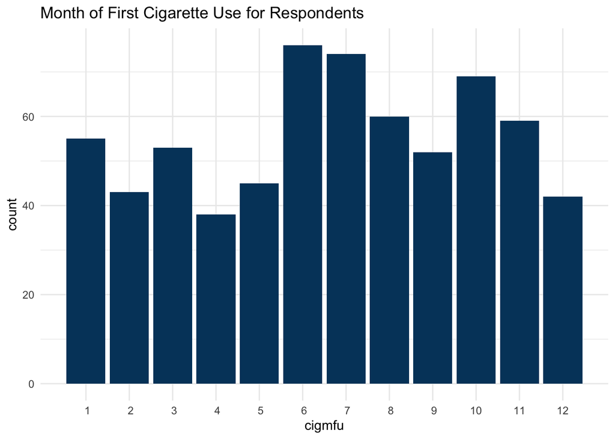

```r
PUF2021_100622 %>%
  select(cigmfu) %>%
  filter(cigmfu <= 12) %>%
  ggplot(aes(x = cigmfu))+
  geom_bar(fill = "#01426A")+
  theme_minimal()+
  labs(title = "Month of First Cigarette Use for Respondents") +
  scale_x_discrete(limits = 1:12)
```